# Assignment 2: Data visualization

Tamas Nagy

You will have to create 3 plots based on the datasets and instructions detailed below. You will find the plots themeselves in the `assignments/assignment_2_plots`. Your task is to write the code that will reproduce the plots as closely as possible.

# Skills needed to solve this assignment

- Using R and RStudio, reading data
- Reporting using RMarkdown
- Using Git and Github (for submitting the task)
- Data manipulation (e.g. dplyr, tidyr), and working with factors (forcats)
- Data visuzlization (ggplot2)

## Task 1: Climbing expeditions

The 2020-09-22 TidyTueday datasets are about climbing expeditions. From the three datasets, use the “expeditions”. Reproduce the plot below! Notice a few things:

- Use `forcats::fct_lump()` to get the 15 most frequent peaks, and drop the “Other” category.
- The bars are ordered by the sum of all expeditions (use `fct_reorder()`).
- The bar colors use the viridis palette and light theme.

## Plotting the 1st graph

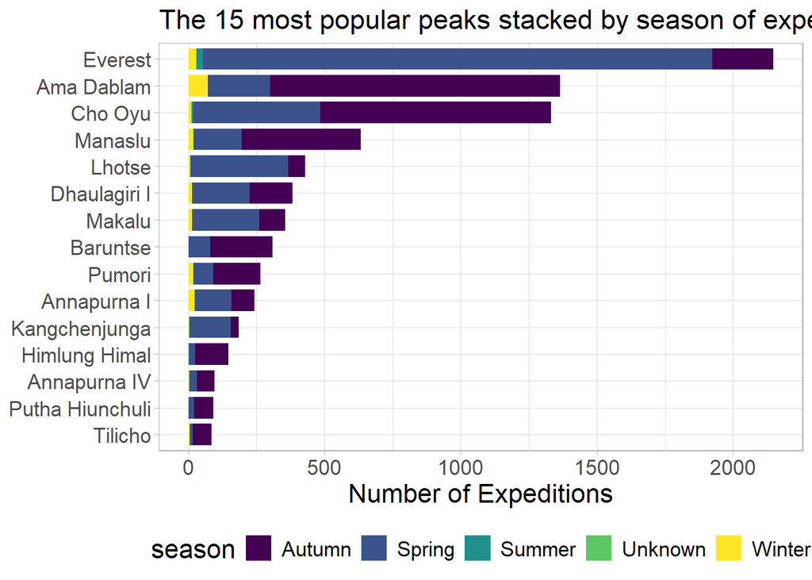

## Saving the plot to check for differences

## Task 2: PhDs awarded

The 2019-02-19 TidyTueday dataset is about phd-s awarded by year and field. There is only one dataset, it is called `phd_by_field`. Reproduce the plot below!

Notes:

- First you have to aggregate the data to count all phd-s by broad fields.
- To make the x axis breaks pretty, use `scales::pretty_breaks()`, to make the y axis labels comma formatted, use `scales::comma_format()`.
- The line size is 1.2, the colors are from the brewer “Dark2” palette. The theme is set to minimal.

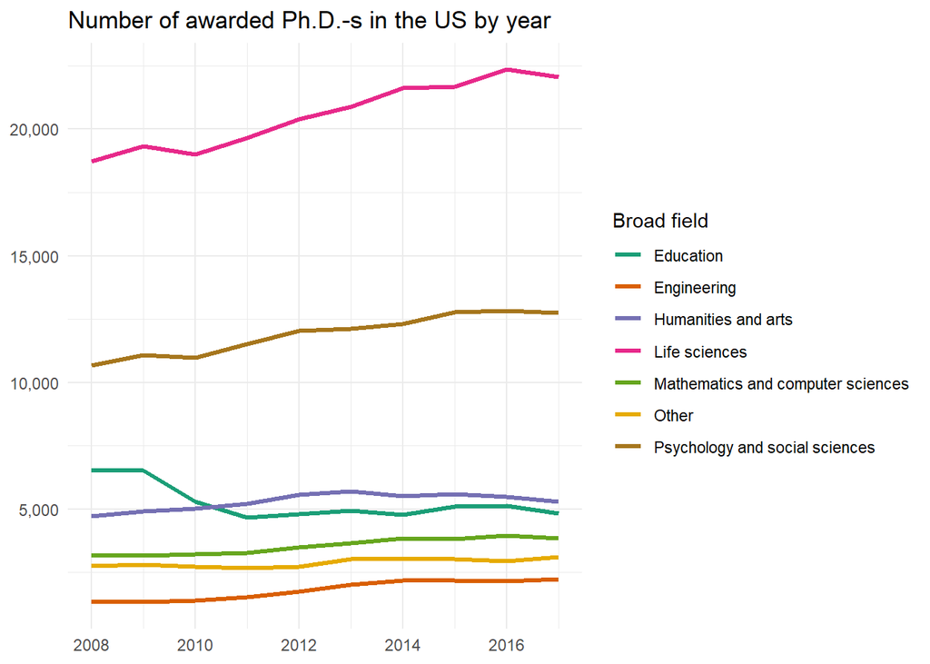

## Plot checking via printing

## Task 3: Commute in the US

The 2019-11-05 TidyTueday dataset is about commuting to work in each city in the US by bike or on foot. There is only one dataset, it is called `commute`. Reproduce the plot below!

Notes:

- First you have to aggregate the data to count all commutes by state.
- Both axis scales are log transformed and the labels comma formatted, using `scales::comma_format()`
- The point size is 2, . The theme is set to light.

## Change from long to wide format

## Plotting

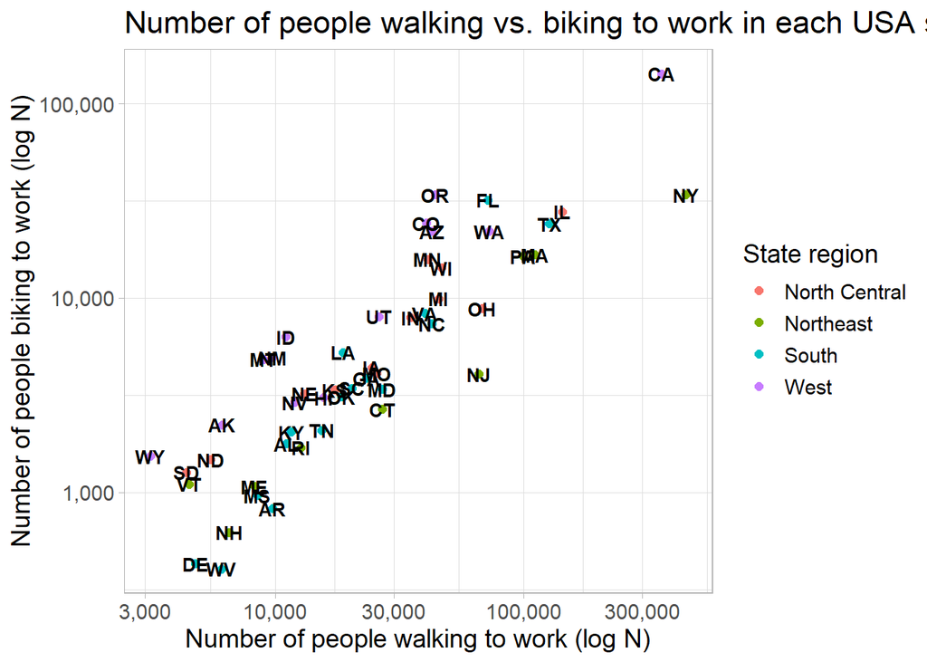

## Saving to check